# Clustering

#### Unsupervied Learning 2020/2021 Winter - Clustering Final Project

#### 436823

## CLUSTERING ON WINE QUALITY DATA

### k-Means Clustering

K-Means clustering is an unsupervised machine learning algorithm which searches for a pre-determined number of clusters within a multidimensional dataset. K-means is a centroid-based algorithm where we calculate the distances to assign a point to a cluster. In K-Means, each cluster is associated with a centroid. There are two main assuptions of k-means algorithm:

- The "cluster center" is the arithmetic mean of all the points belonging to the cluster.
- Each point is closer to its own cluster center than to other cluster centers.

**How it is peformed?**

- Deciding number of clusters(k) and creating centroids.
- Assigning each data point to the closest cluster by calculating its distance with respect to each centroid.
- Determining the new cluster center by computing the average of the assigned points.
- Repeting the process until the cluster assignments do not change anymore.

### Data

The data used is a red wine quality data with some characterictics of variants of the Portuguese "Vinho Verde" wine: https://archive.ics.uci.edu/ml/datasets/wine+quality

It is worth mentioning what each column stands for before running the algorithm in order to be able to comment on our findings.

- fixed acidity: Most acids involved with wine are fixed or nonvolatile (do not evaporate readily).
- volatile acidity: The amount of acetic acid in wine, which at too high of levels can lead to an unpleasant, vinegar taste.
- citric acid: Found in small quantities, citric acid can add 'freshness' and flavor to wines.
- residual sugar: The amount of sugar remaining after fermentation stops, it's rare to find wines with less than 1 gram/liter and wines with greater than 45 grams/liter are considered sweet.
- chlorides: The amount of salt in the wine.
- free sulfur dioxide: The free form of SO2 exists in equilibrium between molecular SO2 (as a dissolved gas) and bisulfite ion; it prevents microbial growth and the oxidation of wine.
- total sulfur dioxide: Amount of free and bound forms of S02; in low concentrations, SO2 is mostly undetectable in wine, but at free SO2 concentrations over 50 ppm, SO2 becomes evident in the nose and taste of wine.
- density: The density of water is close to that of water depending on the percent alcohol and sugar content.
- pH: Describes how acidic or basic a wine is on a scale from 0 (very acidic) to 14 (very basic); most wines are between 3-4 on the pH scale.
- sulphates: A wine additive which can contribute to sulfur dioxide gas (S02) levels, wich acts as an antimicrobial and antioxidant.

```python
from sklearn.preprocessing import StandardScaler
from sklearn.cluster import KMeans
import pandas as pd
import numpy as np
import seaborn as sns
from itertools import cycle, islice
import matplotlib.pyplot as plt
from pandas.plotting import parallel_coordinates

%matplotlib inline
```

```python
data_initial = pd.read_csv(r'C:\Users\Gamze\Desktop\USL\1- Clustering\winedata.csv')
data_initial.head()
```

|  | fixed acidity | volatile acidity | citric acid | residual sugar | chlorides | free sulfur dioxide | total sulfur dioxide | density | pH | sulphates | alcohol | quality |
| --- | --- | --- | --- | --- | --- | --- | --- | --- | --- | --- | --- | --- |
| 0 | 7.4 | 0.70 | 0.00 | 1.9 | 0.076 | 11.0 | 34.0 | 0.9978 | 3.51 | 0.56 | 9.4 | 5 |
| 1 | 7.8 | 0.88 | 0.00 | 2.6 | 0.098 | 25.0 | 67.0 | 0.9968 | 3.20 | 0.68 | 9.8 | 5 |
| 2 | 7.8 | 0.76 | 0.04 | 2.3 | 0.092 | 15.0 | 54.0 | 0.9970 | 3.26 | 0.65 | 9.8 | 5 |
| 3 | 11.2 | 0.28 | 0.56 | 1.9 | 0.075 | 17.0 | 60.0 | 0.9980 | 3.16 | 0.58 | 9.8 | 6 |
| 4 | 7.4 | 0.70 | 0.00 | 1.9 | 0.076 | 11.0 | 34.0 | 0.9978 | 3.51 | 0.56 | 9.4 | 5 |

```python
## Some simple statistics of the variables
data_initial.describe().transpose()
```

|  | count | mean | std | min | 25% | 50% | 75% | max |
| --- | --- | --- | --- | --- | --- | --- | --- | --- |
| fixed acidity | 1599.0 | 8.319637 | 1.741096 | 4.60000 | 7.1000 | 7.90000 | 9.200000 | 15.90000 |
| volatile acidity | 1599.0 | 0.527821 | 0.179060 | 0.12000 | 0.3900 | 0.52000 | 0.640000 | 1.58000 |
| citric acid | 1599.0 | 0.270976 | 0.194801 | 0.00000 | 0.0900 | 0.26000 | 0.420000 | 1.00000 |
| residual sugar | 1599.0 | 2.538806 | 1.409928 | 0.90000 | 1.9000 | 2.20000 | 2.600000 | 15.50000 |
| chlorides | 1599.0 | 0.087467 | 0.047065 | 0.01200 | 0.0700 | 0.07900 | 0.090000 | 0.61100 |
| free sulfur dioxide | 1599.0 | 15.874922 | 10.460157 | 1.00000 | 7.0000 | 14.00000 | 21.000000 | 72.00000 |
| total sulfur dioxide | 1599.0 | 46.467792 | 32.895324 | 6.00000 | 22.0000 | 38.00000 | 62.000000 | 289.00000 |
| density | 1599.0 | 0.996747 | 0.001887 | 0.99007 | 0.9956 | 0.99675 | 0.997835 | 1.00369 |
| pH | 1599.0 | 3.311113 | 0.154386 | 2.74000 | 3.2100 | 3.31000 | 3.400000 | 4.01000 |
| sulphates | 1599.0 | 0.658149 | 0.169507 | 0.33000 | 0.5500 | 0.62000 | 0.730000 | 2.00000 |
| alcohol | 1599.0 | 10.422983 | 1.065668 | 8.40000 | 9.5000 | 10.20000 | 11.100000 | 14.90000 |
| quality | 1599.0 | 5.636023 | 0.807569 | 3.00000 | 5.0000 | 6.00000 | 6.000000 | 8.00000 |

### Plots

Even we decribe the components of the data above, it might be hard to understand how they really affect the quality of data. In the dataset, there is a variable called quality which is an output variable based on sensory data. We can draw barplots to see the relation between the chemical levels and quality of the wine.

In addition, these barplots help us to decide which variables can be differentiating while creating clusters.

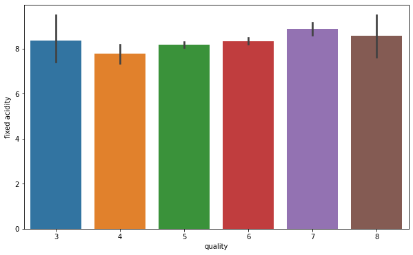

```python
## Fixed acidity
fig = plt.figure(figsize = (10,6))
sns.barplot(x = 'quality', y = 'fixed acidity', data = data_initial)
```

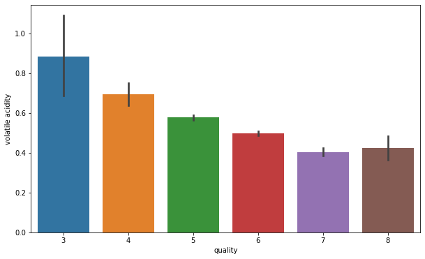

```python
## Volatile acidity
fig = plt.figure(figsize = (10,6))
sns.barplot(x = 'quality', y = 'volatile acidity', data = data_initial)
```

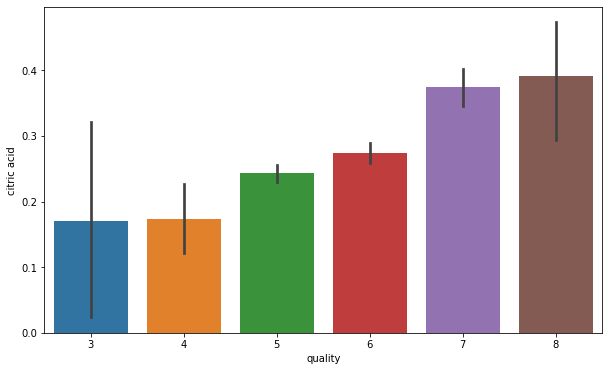

```python
## Citric acid
fig = plt.figure(figsize = (10,6))
sns.barplot(x = 'quality', y = 'citric acid', data = data_initial)
```

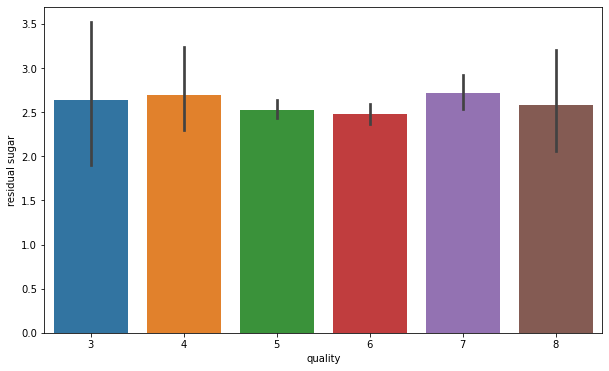

```python
## Residual sugar
fig = plt.figure(figsize = (10,6))
sns.barplot(x = 'quality', y = 'residual sugar', data = data_initial)
```

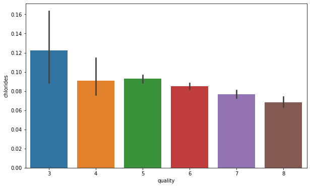

```python
## Chlorides
fig = plt.figure(figsize = (10,6))
sns.barplot(x = 'quality', y = 'chlorides', data = data_initial)
```

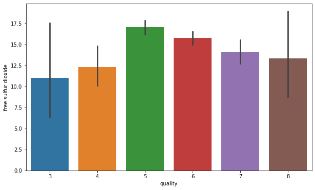

```python
## Free sulfur dioxide
fig = plt.figure(figsize = (10,6))
sns.barplot(x = 'quality', y = 'free sulfur dioxide', data = data_initial)
```

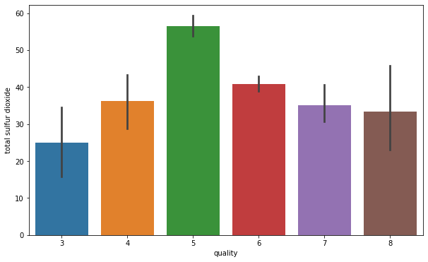

```python
## Total sulfur dioxide
fig = plt.figure(figsize = (10,6))
sns.barplot(x = 'quality', y = 'total sulfur dioxide', data = data_initial)
```

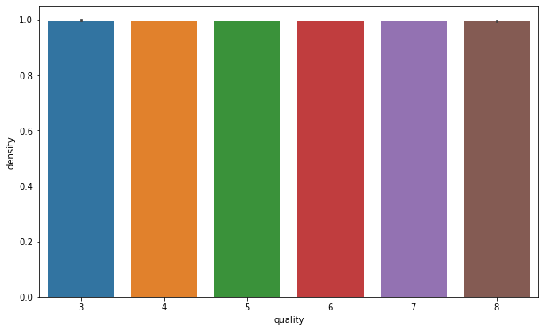

```python
## Density
fig = plt.figure(figsize = (10,6))
sns.barplot(x = 'quality', y = 'density', data = data_initial)
```

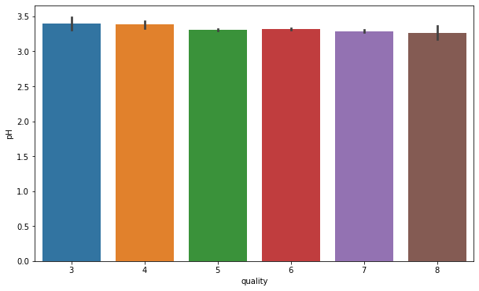

```python
## pH
fig = plt.figure(figsize = (10,6))
sns.barplot(x = 'quality', y = 'pH', data = data_initial)
```

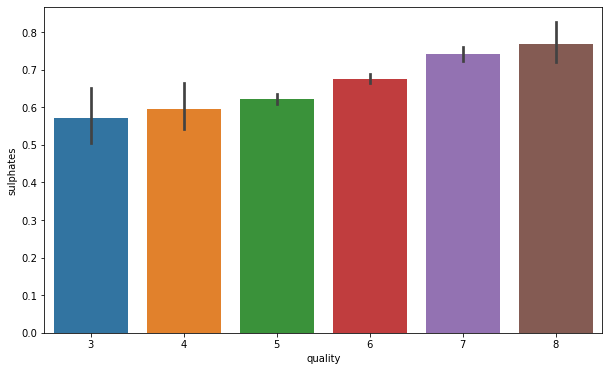

```python
## sulphates
fig = plt.figure(figsize = (10,6))
sns.barplot(x = 'quality', y = 'sulphates', data = data_initial)
```

#### Interpretation of Plots

Plots above show how the column variables are distributed based on different level of quality. Some almost does not vary with respect to the quality of wime, whereas some changes significantly. It might be benefical to drop the variables that are more or less the same in different level of quality to have more working space.

```python
## Selection of wine features what can be used in clustering
features = ['fixed acidity', 'volatile acidity', 'citric acid', 'residual sugar', 'chlorides', 'free sulfur dioxide',
            'total sulfur dioxide', 'sulphates']

data = data_initial[features]
data
```

|  | fixed acidity | volatile acidity | citric acid | residual sugar | chlorides | free sulfur dioxide | total sulfur dioxide | sulphates |
| --- | --- | --- | --- | --- | --- | --- | --- | --- |
| 0 | 7.4 | 0.700 | 0.00 | 1.9 | 0.076 | 11.0 | 34.0 | 0.56 |
| 1 | 7.8 | 0.880 | 0.00 | 2.6 | 0.098 | 25.0 | 67.0 | 0.68 |
| 2 | 7.8 | 0.760 | 0.04 | 2.3 | 0.092 | 15.0 | 54.0 | 0.65 |
| 3 | 11.2 | 0.280 | 0.56 | 1.9 | 0.075 | 17.0 | 60.0 | 0.58 |
| 4 | 7.4 | 0.700 | 0.00 | 1.9 | 0.076 | 11.0 | 34.0 | 0.56 |
| ... | ... | ... | ... | ... | ... | ... | ... | ... |
| 1594 | 6.2 | 0.600 | 0.08 | 2.0 | 0.090 | 32.0 | 44.0 | 0.58 |
| 1595 | 5.9 | 0.550 | 0.10 | 2.2 | 0.062 | 39.0 | 51.0 | 0.76 |
| 1596 | 6.3 | 0.510 | 0.13 | 2.3 | 0.076 | 29.0 | 40.0 | 0.75 |
| 1597 | 5.9 | 0.645 | 0.12 | 2.0 | 0.075 | 32.0 | 44.0 | 0.71 |
| 1598 | 6.0 | 0.310 | 0.47 | 3.6 | 0.067 | 18.0 | 42.0 | 0.66 |

1599 rows × 8 columns

```python
## Scaling the features using StandardScaler
data_s = StandardScaler().fit_transform(data)
data_s
```

```
array([[-0.52835961,  0.96187667, -1.39147228, ..., -0.46619252,
        -0.37913269, -0.57920652],
       [-0.29854743,  1.96744245, -1.39147228, ...,  0.87263823,
         0.62436323,  0.1289504 ],
       [-0.29854743,  1.29706527, -1.18607043, ..., -0.08366945,
         0.22904665, -0.04808883],
       ...,
       [-1.1603431 , -0.09955388, -0.72391627, ...,  1.2551613 ,
        -0.19667889,  0.54204194],
       [-1.39015528,  0.65462046, -0.77526673, ...,  1.54205361,
        -0.07504302,  0.30598963],
       [-1.33270223, -1.21684919,  1.02199944, ...,  0.20322286,
        -0.13586095,  0.01092425]])
```

```python
## Applying k-Means clustering

kmeans = KMeans(n_clusters=3)
model = kmeans.fit(data_s)
print("model\n", model)
```

```
model
 KMeans(n_clusters=3)
```

```python
## What are the centers of the clusters?
centers = model.cluster_centers_
centers
```

```
array([[-0.55777626,  0.59842017, -0.79539056, -0.21763125, -0.14021446,
        -0.37738226, -0.40657381, -0.38949632],
       [-0.23954509, -0.0625827 ,  0.03422426,  0.30480695, -0.08270377,
         1.11837707,  1.18252153,  0.0337338 ],
       [ 0.97966507, -0.75962814,  1.05430393,  0.01906419,  0.26677461,
        -0.50479756, -0.52345066,  0.50080534]])
```

```python
## Creating a DataFrame with a column for cluster number
def pd_centers(featuresUsed, centers):
    colNames = list(featuresUsed)
    colNames.append('prediction')

    # Zip with a column called 'prediction' (index)
    Z = [np.append(A, index) for index, A in enumerate(centers)]

    # Convert to pandas data frame for plotting
    P = pd.DataFrame(Z, columns=colNames)
    P['prediction'] = P['prediction'].astype(int)
    return P
```

```python
## Creating Parallel Plots
def parallel_plot(data):
    my_colors = list(islice(cycle(['b', 'r', 'g', 'y', 'k']), None, len(data)))
    plt.figure(figsize=(15,8)).gca().axes.set_ylim([-3,+3])
    parallel_coordinates(data, 'prediction', color = my_colors, marker='o')
```

```python
P = pd_centers(features, centers)
P
```

|  | fixed acidity | volatile acidity | citric acid | residual sugar | chlorides | free sulfur dioxide | total sulfur dioxide | sulphates | prediction |
| --- | --- | --- | --- | --- | --- | --- | --- | --- | --- |
| 0 | -0.557776 | 0.598420 | -0.795391 | -0.217631 | -0.140214 | -0.377382 | -0.406574 | -0.389496 | 0 |
| 1 | -0.239545 | -0.062583 | 0.034224 | 0.304807 | -0.082704 | 1.118377 | 1.182522 | 0.033734 | 1 |
| 2 | 0.979665 | -0.759628 | 1.054304 | 0.019064 | 0.266775 | -0.504798 | -0.523451 | 0.500805 | 2 |

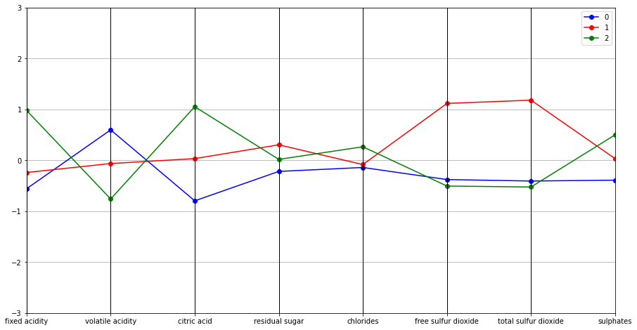

```python
parallel_plot(P)
```

#### Conclusion

We have three clusters which represents different level of wine quality with respect to values of the chemical level of ingredients in wines. Even some points almost intersects in the plot above, they create unique clusters when combined with other features of wines.

#### References

https://www.vinhoverde.pt/en/

https://archive.ics.uci.edu/ml/datasets/wine+quality

https://jakevdp.github.io/PythonDataScienceHandbook/05.11-k-means.html

https://www.analyticsvidhya.com/blog/2019/08/comprehensive-guide-k-means-clustering/